# Maladie à Virus Ebola — Situation Report Extraction

Democratic Republic of Congo

Author

Billy J Quilty (Charité Berlin, LSHTM & MSF Epicentre)

Published

10 June 2026

**Warning**

**Automated extraction — verification required.** Case counts and figures in this report are extracted from INSP DRC PDF situation reports by an AI vision model (Anthropic Claude `claude-sonnet-4-6`) without systematic manual verification of every value. Extraction errors are possible, particularly where PDF table layouts are complex or inconsistent. All values should be verified against the [original INSP DRC situation reports](https://insp.cd/ebola/) before any operational, clinical, or policy use. This report is intended for research and situational awareness only.

## Methods

### Data sources

Case counts were taken from the INSP DRC situation report PDFs, downloaded automatically from https://insp.cd/ebola/. Where our PDF copies and the INRB-UMIE copies overlap, file checksums confirm they are identical, so any differences between the two datasets come from how the tables were read rather than which documents were used. The INRB-UMIE series, produced by manual data entry, was used as an independent check on our automated extraction.

### Automated PDF extraction

Each PDF is read by Claude (Anthropic, `claude-sonnet-4-6`) using visual understanding of the page layout, allowing it to handle the complex table structures accurately. Four datasets are extracted from each report: daily new case counts, cumulative case and death totals, patient movement through isolation units (available from SitRep 006 onwards), and Point of Entry screening activity. A full text transcript is also saved for audit purposes.

### Data harmonisation

Health zone names were standardised to a consistent spelling across all reports. Suspected and probable case counts were summed into a single “unconfirmed” category, since the column labels vary across reports. Cumulative totals were not permitted to decrease over time, and where more than one row existed for the same zone and date the higher value was retained.

### Statistical analysis

All analysis and figures were produced in R (version 4.5.1) using the `tidyverse` [@tidyverse], `ggplot2` [@ggplot2], and `flextable` [@flextable] packages. This report was rendered automatically with Quarto.

### Cross-source validation

We checked our automated extraction against the [INRB-UMIE Ebola DRC 2026](https://github.com/INRB-UMIE/Ebola_DRC_2026) manually coded dataset, which extends through SitRep 22 (6 June 2026) in the current build. For SitReps 1–11 both datasets use the same PDF files, so differences reflect extraction method rather than source documents. From SitRep 12 onwards INRB-UMIE note that health-zone data is occasionally sent directly from INSP to INRB and may not feature in the published PDFs; this explains divergence at zone level from SitRep 12 onwards. Two zone name variants (Mongbwalu/Mongbalu and Nyankunde/Nyakunde) were matched manually; values marked “ND” were treated as missing.

## Results

The following sections compare our automated extraction against the INRB-UMIE manually coded dataset and document known data quality issues in the source PDFs.

### National-level comparison — this repo and INRB-UMIE

Table 1: National cumulative totals — cross-source comparison (this repo vs INRB-UMIE). Shading indicates values that differ. INRB-UMIE: INRB-UMIE/Ebola DRC 2026. A dash indicates no data available from that source for that date.

| Date | Suspected cases Suspect. (ours) | Suspected cases Suspect. (INRB-UMIE) | Confirmed cases Confirmed (ours) | Confirmed cases Confirmed (INRB-UMIE) | Deaths Deaths (ours) | Deaths Deaths susp. (INRB-UMIE) | Deaths Deaths conf. (INRB-UMIE) |
| --- | --- | --- | --- | --- | --- | --- | --- |
| 14 May | — | 246 | — | 8 | — | — | 4 |
| 17 May | — | 246 | — | 13 | — | — | 4 |
| 18 May | 516 | 516 | 33 | 33 | 131 | 131 | 4 |
| 19 May | 575 | 575 | 51 | 51 | 148 | 148 | 4 |
| 20 May | 671 | 671 | 61 | 64 | 160 | 160 | 6 |
| 21 May | 746 | 746 | 83 | 83 | 176 | 176 | 9 |
| 22 May | 867 | 867 | 91 | 91 | 204 | — | 10 |
| 23 May | 904 | 904 | 101 | 101 | 119 | 220 | 10 |
| 24 May | 906 | 906 | 105 | 105 | 223 | 223 | 10 |
| 25 May | 998 | 998 | 106 | 106 | 238 | 238 | 12 |
| 26 May | 1,077 | 1,077 | 121 | 121 | 246 | 246 | 17 |
| 27 May | 906 | 906 | 125 | 125 | 223 | 223 | 17 |
| 28 May | 349 | 349 | 210 | 210 | 17 | 236 | 17 |
| 29 May | — | 349 | 263 | 263 | 42 | 236 | 42 |
| 30 May | — | 321 | 282 | 238 | 42 | 236 | 42 |
| 31 May | — | 220 | 321 | 321 | 48 | — | 48 |
| 01 Jun | — | 289 | 344 | 344 | 60 | 242 | 60 |
| 02 Jun | — | 206 | 363 | 363 | 62 | — | 62 |
| 03 Jun | — | — | 381 | 381 | 64 | — | 64 |
| 04 Jun | — | 153 | 452 | 452 | 82 | — | 82 |
| 05 Jun | — | 119 | 488 | 488 | 86 | — | 86 |
| 06 Jun | — | 117 | 515 | 515 | 91 | — | 91 |
| 07 Jun | — | 94 | 550 | 550 | 101 | — | 101 |
| 08 Jun | — | — | 598 | — | 115 | — | — |

### Data quality notes — case counts

**Suspect and probable case reporting discontinued.** From SitRep 015 (29 May) onwards, INSP stopped publishing cumulative suspect/probable breakdowns in the zone tables. From SitRep 016 (30 May) onwards they are absent from both cumulative and daily new-cases tables at all geographic levels. SitRep 014 stated explicitly that suspected deaths were temporarily excluded pending investigation results (*“Les décès suspects ont été temporairement exclus du comptage dans l’attente des résultats des investigations en cours”*). The orange-shaded region in the national “Suspected deaths” panel marks this ongoing series break.

**INRB-UMIE suspected cases after SitRep 016 are not cumulative.** From SitRep 016 onwards, INSP’s banner split suspect reporting into ‘Cas suspects en cours d’investigation’ (under investigation) and ‘Cas suspects en isolement’ (in isolation). INRB-UMIE sum these two active categories as their national suspected case figure. This means the INRB-UMIE suspected case series from SitRep 016 onwards reflects **active suspects at a point in time**, not cumulative ever-suspected — explaining the declining trend.

### Daily new cases (national)

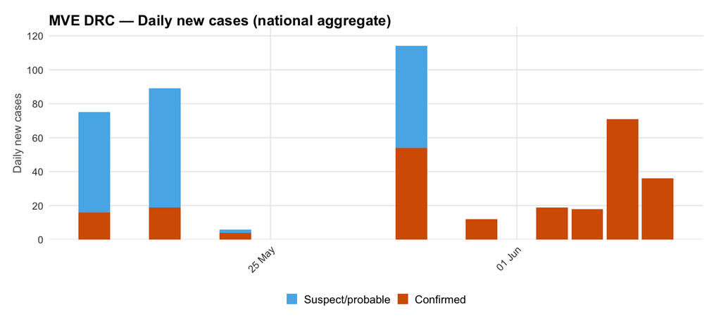

Figure 1: Daily new cases reported nationally by case classification (from ‘Nouveaux’ rows in each SitRep). Suspect/probable cases absent from SitRep 016 onwards.

### Cumulative counts by zone and source

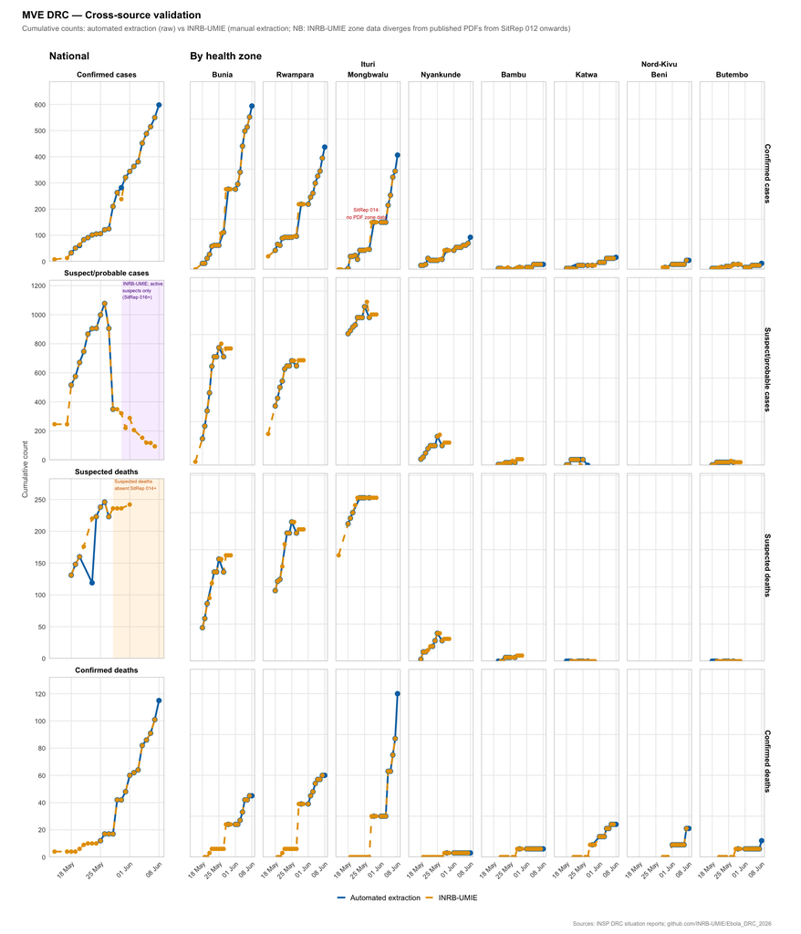

Figure 2: Cross-source comparison of cumulative confirmed cases, suspect/probable cases, and outbreak deaths by health zone. Solid lines: automated extraction (raw); dashed lines: INRB-UMIE (manual extraction). For SitReps 1–11 both sources use the same PDFs; from SitRep 12 onwards INRB-UMIE zone data may include figures sent directly from INSP to INRB that do not appear in the published PDFs. From SitRep 16 onwards INRB-UMIE national suspected cases reflect active suspects (under investigation + in isolation), not cumulative totals.

Table 2 summarises numerical differences at the most recent date available in each source per zone.

Table 2: Cumulative case counts at the latest available date per zone: automated extraction vs INRB-UMIE. Δ = ours minus INRB-UMIE. Dashes indicate no data in that source. Note: INRB-UMIE zone data from SitRep 12 onwards diverges from the published PDFs (exact supplementary source not documented in their public repository).

| Health zone | Confirmed (ours) | Confirmed (INRB-UMIE) | Δ confirmed | Suspect/prob. (ours) | Suspect/prob. (INRB-UMIE) | Δ suspect/prob. | Deaths (ours) | Deaths (INRB-UMIE) | Δ deaths |
| --- | --- | --- | --- | --- | --- | --- | --- | --- | --- |
| Bambu | 5 | 5 | 0 |  |  |  | 2 | 2 | 0 |
| Beni | 9 | 9 | 0 |  |  |  | 7 | 7 | 0 |
| Bunia | 163 | 152 | 11 |  |  |  | 55 | 15 | 40 |
| Butembo | 6 | 4 | 2 |  |  |  | 4 | 2 | 2 |
| Katwa | 12 | 11 | 1 |  |  |  | 8 | 8 | 0 |
| Mongbwalu | 114 | 98 | 16 |  |  |  | 88 | 29 | 59 |
| Nyankunde | 32 | 26 | 6 |  |  |  | 15 | 1 | 14 |
| Rwampara | 122 | 111 | 11 |  |  |  | 75 | 20 | 55 |

### Data quality notes — response indicators

- **Rwampara 21 May (SitRep 007).** Data are split across three unlabelled sub-columns; both datasets handle these differently. Values for that date should be treated with caution.
- **20–21 May (SitReps 005–006).** An earlier table layout made in-bed count and new admissions columns ambiguous; minor differences between datasets on those dates result from this. Agreement is close from 22 May onwards when the format was standardised.
- **Coverage.** INRB-UMIE (`build-2026-06-07`) extends through 6 June 2026; our extraction covers through SitRep 023 (7 June 2026). Validation panels overlap through 6 June 2026.

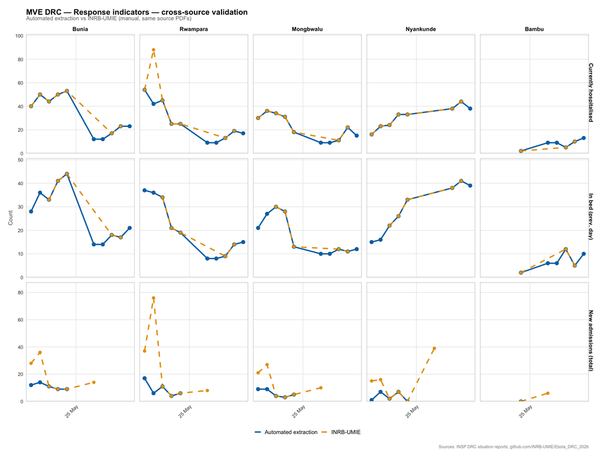

Figure 3: Cross-source comparison of zone-level response indicators. Solid lines: automated extraction; dashed lines: INRB-UMIE. Both series treat the ambiguous 21 May Rwampara sub-columns differently; values for that date should be interpreted cautiously. The two datasets differ slightly on 20–21 May due to an ambiguous table layout in SitReps 005–006, and are in close agreement from 22 May onwards.

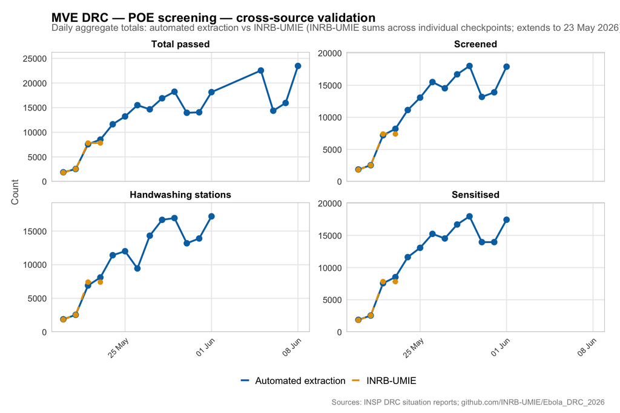

Figure 4: Cross-source comparison of daily Point of Entry (POE) screening totals. Automated extraction reports a single aggregate per sitrep date; INRB-UMIE data are summed across individual checkpoints to produce a daily total.

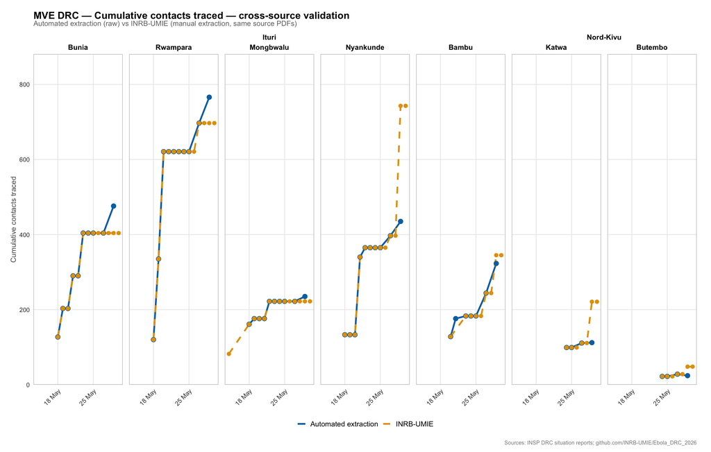

Figure 5: Cross-source comparison of cumulative contacts traced by health zone. Solid lines: automated extraction (raw); dashed lines: INRB-UMIE (manual extraction). ND values excluded.

## Discussion

**Outbreak trajectory**

## Appendix — Internal consistency check

#### Zone sum vs national aggregate

Cumulative zone-row sums are compared with the national banner figure for each date. Highlighted rows (non-zero Δ) arise from three causes:

Table 3: Zone sum vs national aggregate. Values show the cumulative total across all extracted health zones versus the national figure from the front-page banner. Δ = zone sum minus national banner. Highlighted rows have a non-zero difference in at least one metric.

| Date | Suspected Zones (susp.) | Suspected Nat. (susp.) | Suspected Δ susp. | Confirmed Zones (conf.) | Confirmed Nat. (conf.) | Confirmed Δ conf. | Deaths Zones (deaths) | Deaths Nat. (deaths) | Deaths Δ deaths |
| --- | --- | --- | --- | --- | --- | --- | --- | --- | --- |
| 18 May | 515 | 516 | -1 | 32 | 33 | -1 | 131 | 131 | 0 |
| 19 May | 574 | 575 | -1 | 50 | 51 | -1 | 148 | 148 | 0 |
| 20 May | 671 | 671 | 0 | 56 | 61 | -5 | 160 | 160 | 0 |
| 21 May | 741 | 746 | -5 | 75 | 83 | -8 | 175 | 176 | -1 |
| 22 May | 852 | 867 | -15 | 79 | 91 | -12 | 201 | 204 | -3 |
| 23 May | 887 | 904 | -17 | 89 | 101 | -12 | 215 | 119 | 96 |
| 24 May | 887 | 906 | -19 | 91 | 105 | -14 | 218 | 223 | -5 |
| 25 May | 966 | 998 | -32 | 91 | 106 | -15 | 235 | 238 | -3 |
| 27 May | 874 | 906 | -32 | 109 | 125 | -16 | 218 | 223 | -5 |
| 29 May |  |  |  | 224 | 263 | -39 | 39 | 42 | -3 |
| 01 Jun |  |  |  | 227 | 344 | -117 | 44 | 60 | -16 |
| 02 Jun |  |  |  | 242 | 363 | -121 | 46 | 62 | -16 |
| 03 Jun |  |  |  | 258 | 381 | -123 | 48 | 64 | -16 |
| 04 Jun |  |  |  | 320 | 452 | -132 | 65 | 82 | -17 |
| 05 Jun |  |  |  | 354 | 488 | -134 | 69 | 86 | -17 |
| 06 Jun |  |  |  | 381 | 515 | -134 | 74 | 91 | -17 |
| 07 Jun |  |  |  | 416 | 550 | -134 | 84 | 101 | -17 |
| 08 Jun |  |  |  | 463 | 598 | -135 | 97 | 115 | -18 |